# Diego_Rosado_ml1_Modelo_Predictivo

Diego Rosado

2023-02-28

Github: https://github.com/DiegoRosado426/ml_class

### Introducción al dataset

El dataset utilizando para crear este modelo predictivo proviene de un conjunto de datos creado por Dr. William H. Wolberg para el cancer de mama en *University of Wisconsin Hospitals, Madison*. Las muestras llegaban de manera periódica mientras Dr. Wolberg hacía reportajes sobre sus casos clínicos. Este conjunto de datos tiene un total de 699 instancias donde cada una contiene once atributos. Por último, nuestra variable *target* para este conjunto de datos es *Class* que es una variable categórica compuesta por dos niveles, *Benign* y *Malignant.* A través de los valores que le corresponden a las variables predictoras, podremos determinar el valor de la variable *target* que nos dice si el tumor es benigno o maligno.

Antes de poder crear nuestros modelos para el conjunto de datos, es necesario limpiar y modificar los datos para que se puedan utilizar de una manera adecuada. Para este archivo que contiene los datos, hemos eliminado los separadores que dividen cada columna que en el caso de los datos de *training* eran “h_”. Luego hemos creado un data frame con los datos y le hemos asignado el nombre correspondiente a cada columna. En la base de datos, se encontraban valores con signos interrogativos que identificaban los valores NA y los hemos identificado de esa manera en el data frame. Adicionalmente, había una cantidad de valores que no caían dentro del rango de valores posibles para cada variable y se tomaron las decisiones adecuadas para poder incluir estos valores. Por ejemplo, como los valores posibles para cada variable van del 1-10, si aparecía un valor igual a 20, se le asignaba el valor de 2 y así hicimos con los otros valores inapropiados en el dataset. Por último, hemos clasificado aquellas variables que van desde la columna 1 hasta la 10 como variables numéricas y aquellas en las columnas 11 y 12 como categóricas. Las columnas 11 y 12 le corresponden a *Group* y *Class,* respectivamente.

```r
dataset <-  read.csv("Breast_Cancer_train.data",sep = "h", header = FALSE)
mis_datos <- data.frame(lapply(X = dataset, FUN = function(t) gsub(pattern = "_", replacement = "", x = t, fixed = TRUE)))
colnames(mis_datos) <- c("Sample_Code_Number","Clump_Thickness","Uniformity_of_Cell_Size","Uniformity_of_Cell_Shape","Marginal_Adhesion","Single_Epithelial_Cell_Size","Bare_Nuclei","Bland_Chromatin","Normal_Nucleoli","Mitoses","Group","Class")

# Columna: Class
mis_datos[mis_datos == "?"] <- NA
unique(mis_datos$Class)
```

```
## [1] "2"  "4"  "3"  "44" "20" NA
```

```r
mis_datos$Class[mis_datos$Class == "3"] <- NA
mis_datos$Class[mis_datos$Class == "44"] <- 4
mis_datos$Class[mis_datos$Class == "20"] <- 2
mis_datos$Class <- as.factor(mis_datos$Class)
levels(mis_datos$Class) <- c("Benign","Malignant")

# Columna: Group
unique(mis_datos$Group)
```

```
## [1] "1" "6" "2" "8" "7" "5" "3" "4"
```

```r
mis_datos$Group <- as.factor(mis_datos$Group)
levels(mis_datos$Group) <- c('Group_1','Group_2','Group_3','Group_4','Group_5','Group_6','Group_7','Group_8')

# Columnas numéricas
library("dplyr")
mis_datos <- mis_datos%>%
  mutate_at(c("Sample_Code_Number","Clump_Thickness","Uniformity_of_Cell_Size","Uniformity_of_Cell_Shape","Marginal_Adhesion","Single_Epithelial_Cell_Size","Bare_Nuclei","Bland_Chromatin","Normal_Nucleoli","Mitoses"), as.numeric)
tipo_clase <- sapply(mis_datos,class)

# Columna Clump_Thickness
unique(mis_datos$Clump_Thickness)
```

```
##  [1]   5   3   2  10   4   1   7   6   8   9 100  30
```

```r
mis_datos$Clump_Thickness[mis_datos$Clump_Thickness == 100] <- 10
mis_datos$Clump_Thickness[mis_datos$Clump_Thickness == 30] <- 3

# Columna Uniformity_of_Cell_Size
unique(mis_datos$Uniformity_of_Cell_Size)
```

```
##  [1]  1  3 10  6  2  7  8  9  5 NA  4 30
```

```r
mis_datos$Uniformity_of_Cell_Size[mis_datos$Uniformity_of_Cell_Size == 30] <- 3

# Columna Uniformity_of_Cell_Shape
unique(mis_datos$Uniformity_of_Cell_Shape)
```

```
##  [1]  1  3  2 10  6  7  4  5  9  8 NA 80 -7
```

```r
mis_datos$Uniformity_of_Cell_Shape[mis_datos$Uniformity_of_Cell_Shape == 80] <- 8
mis_datos$Uniformity_of_Cell_Shape[mis_datos$Uniformity_of_Cell_Shape == -7] <- 7

# Columna Marginal_Adhesion
unique(mis_datos$Marginal_Adhesion)
```

```
##  [1]   1   2   8   6   7   3  10   5   4 100   9  -1
```

```r
mis_datos$Marginal_Adhesion[mis_datos$Marginal_Adhesion == 100] <- 10
mis_datos$Marginal_Adhesion[mis_datos$Marginal_Adhesion == -1] <- 1

# Columna Single_Epithelial_Cell_Size
unique(mis_datos$Single_Epithelial_Cell_Size)
```

```
##  [1]   2   3   5   1  10   4   6   8   7  60   9 100
```

```r
mis_datos$Single_Epithelial_Cell_Size[mis_datos$Single_Epithelial_Cell_Size == 60] <- 6
mis_datos$Single_Epithelial_Cell_Size[mis_datos$Single_Epithelial_Cell_Size == 100] <- 10

# Columna Bare_Nuclei
unique(mis_datos$Bare_Nuclei)
```

```
##  [1]  1 10  3  8  5  7  9  2  4 NA  6
```

```r
# Columna Bland_Chromatin
unique(mis_datos$Bland_Chromatin)
```

```
##  [1]  3  2  1  4  6  5  7  8 10  9 11
```

```r
mis_datos$Bland_Chromatin[mis_datos$Bland_Chromatin == 11] <- 1

# Columna Normal_Nucleoli
unique(mis_datos$Normal_Nucleoli)
```

```
##  [1]  1  8  4  7  2  3  6  5  9 10 NA
```

```r
df_mis_variables <- data.frame(tipo_de_clase = tipo_clase)
```

### Distribución variables numéricas

Para poder visualizar la distribución de los valores para las variables numéricas, hemos creado unos boxplots en donde dividimos los valores entre los pacientes que sí tienen un tumor benigno y aquellos que tienen un tumor maligno. Como tenemos 9 variables numéricas en nuestro conjunto de datos, hemos creado 9 boxplots distintas para cada variable.

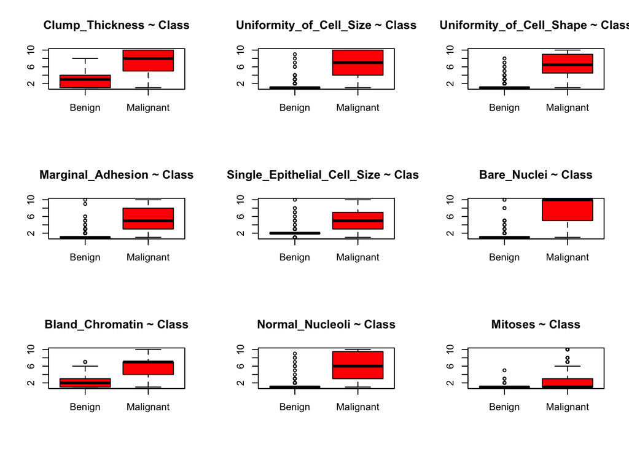

```r
par(mfrow = c(3,3))
for(i in 2:10) {
  boxplot(mis_datos[,i] ~ mis_datos[,12], main =paste0(names(mis_datos[i])," ~ Class" ), xlab = NULL, ylab = NULL, col = "red")
}
```

### Distribución variables categóricas

Para poder observar la distribución de la otra variable categórica en el dataset aparte de nuestra variable *target*, no podemos utilizar un boxplot como hicimos con las variables numéricas. Es por eso que utilizamos barplots para poder observar las distribución de esta variable. Los niveles de esta variable categórica luego son divididos entre ocho grupos que le corresponden a cada reportaje del Dr. Wolberg con una cierta cantidad de casos clínicos.

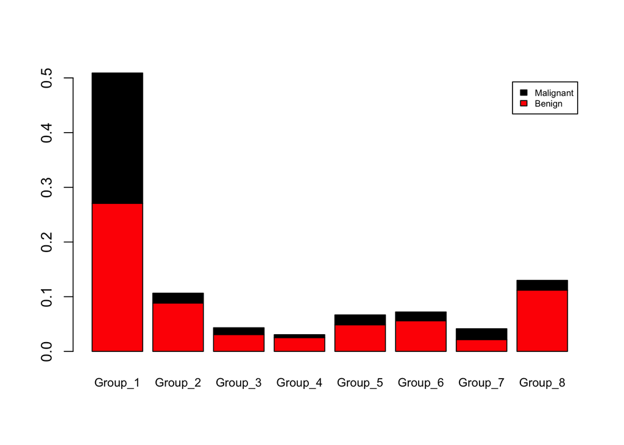

```r
valores = table(mis_datos[,12],mis_datos[,11])
proporciones1 = prop.table(valores)
barplot(proporciones1, main = colnames(mis_datos[,11]),legend.text = TRUE,args.legend = list(cex = 0.60), cex.names = 0.8, col = c("red","black"),beside = FALSE)
```

### Modelos lineales generalizados para variables numéricas

Los modelos lineales son utilizados para observar el efecto que tiene la variable independiente en la variable dependiente e identificar si influye de manera estadísticamente significativa. Es por eso que hemos realizado modelos lineales generalizados para la variable dependiente (que en este caso es si el paciente tiene un tumor maligno o benigno) en función de las variables numéricas que son las variables independientes.Para estos modelos, hemos considerado un valor p significativo como uno menor de 0,05. Luego de adquirir los valores p de los modelos, cada uno salió estadísticamente significativo.

```r
mis_pvalores_var_num <- NULL
for (i in 2:10){
  modelos_num <- glm(mis_datos[,12] ~ mis_datos[,i], family = binomial(link = "logit"))
  mis_pvalores_var_num <- c(mis_pvalores_var_num,(summary(modelos_num)$coefficients[2,4]))

}
nombres_variables <- names(mis_datos[2:10])
mis_pvalores_var_num <- data.frame(mis_pvalores_var_num,row.names = nombres_variables)
colnames(mis_pvalores_var_num)[1] <- "pvalores"
```

### Modelos lineales generalizados para variables categóricas

```r
mis_pvalores_var_fac <- NULL
modelo_var_fac <- glm(mis_datos[,12] ~ mis_datos[,11], family = binomial(link = "logit"))
mis_pvalores_var_fac <- c(mis_pvalores_var_fac, (summary(modelo_var_fac)$coefficients[1:max(nlevels(mis_datos[,11])),4]))
mis_pvalores_var_fac <- data.frame(mis_pvalores_var_fac,row.names = levels(mis_datos$Group))
colnames(mis_pvalores_var_fac)[1] <- "pvalores"
```

Luego de adquirir los valores p de cada modelo, hemos unido todos los valores p en un data frame con dos columnas. En una columna tenemos los nombres de cada variable y los niveles de nuestra variable categórica *Group*. En la siguiente columna tenemos los valores p que le corresponden a cada nombre.

```r
#Unir pvalores para ambos tipos de variables
mis_pvalores <- rbind(mis_pvalores_var_num,mis_pvalores_var_fac)
```

### Dummy variables

Antes de crear nuestros modelos multivariantes, es necesario crear a lo que se consideran variables dummy. Se crean estas variables porque al hacerlas, podemos identificar el nivel al que pertenecen las observaciones.

```r
#Crear dummies
Group1 <- ifelse(mis_datos$Group == 'Group_1',0,1)
Group2 <- ifelse(mis_datos$Group == 'Group_2',0,1)
Group3 <- ifelse(mis_datos$Group == 'Group_3',0,1)
Group4 <- ifelse(mis_datos$Group == 'Group_4',0,1)
Group5 <- ifelse(mis_datos$Group == 'Group_5',0,1)
Group6 <- ifelse(mis_datos$Group == 'Group_6',0,1)
Group7 <- ifelse(mis_datos$Group == 'Group_7',0,1)
Group8 <- ifelse(mis_datos$Group == 'Group_8',0,1)
```

### Modelos Multivariantes

```r
modelo_multivariante <- glm(Class ~ Clump_Thickness + Uniformity_of_Cell_Size + Uniformity_of_Cell_Shape + Marginal_Adhesion + Single_Epithelial_Cell_Size + Bare_Nuclei + Bland_Chromatin + Normal_Nucleoli + Mitoses + Group2 + Group4 + Group5 + Group6 + Group8, data = mis_datos, family = binomial(link = "logit"))
summary(modelo_multivariante)
```

```
##
## Call:
## glm(formula = Class ~ Clump_Thickness + Uniformity_of_Cell_Size +
##     Uniformity_of_Cell_Shape + Marginal_Adhesion + Single_Epithelial_Cell_Size +
##     Bare_Nuclei + Bland_Chromatin + Normal_Nucleoli + Mitoses +
##     Group2 + Group4 + Group5 + Group6 + Group8, family = binomial(link = "logit"),
##     data = mis_datos)
##
## Deviance Residuals:
##      Min        1Q    Median        3Q       Max
## -3.04101  -0.08233  -0.03264   0.01354   2.38749
##
## Coefficients:
##                              Estimate Std. Error z value Pr(>|z|)
## (Intercept)                 -20.13681    8.46702  -2.378  0.01739 *
## Clump_Thickness               0.64861    0.20649   3.141  0.00168 **
## Uniformity_of_Cell_Size       0.07529    0.28405   0.265  0.79098
## Uniformity_of_Cell_Shape      0.24773    0.30263   0.819  0.41302
## Marginal_Adhesion             0.36832    0.15676   2.350  0.01880 *
## Single_Epithelial_Cell_Size  -0.02672    0.17619  -0.152  0.87948
## Bare_Nuclei                   0.33146    0.11016   3.009  0.00262 **
## Bland_Chromatin               0.53444    0.21202   2.521  0.01171 *
## Normal_Nucleoli               0.34238    0.14957   2.289  0.02207 *
## Mitoses                       0.60838    0.60354   1.008  0.31344
## Group2                        3.68265    1.74582   2.109  0.03491 *
## Group4                        2.76381    7.25207   0.381  0.70312
## Group5                       -0.22311    1.26643  -0.176  0.86016
## Group6                        1.56457    2.07367   0.754  0.45055
## Group8                        1.88579    1.62416   1.161  0.24561
## ---
## Signif. codes:  0 '***' 0.001 '**' 0.01 '*' 0.05 '.' 0.1 ' ' 1
##
## (Dispersion parameter for binomial family taken to be 1)
##
##     Null deviance: 695.780  on 535  degrees of freedom
## Residual deviance:  71.833  on 521  degrees of freedom
##   (23 observations deleted due to missingness)
## AIC: 101.83
##
## Number of Fisher Scoring iterations: 9
```

```r
modelo_multivariante <- glm(Class ~ Clump_Thickness + Marginal_Adhesion + Bare_Nuclei + Bland_Chromatin + Normal_Nucleoli + Group2, data = mis_datos, family = binomial(link = "logit"))
summary(modelo_multivariante)
```

```
##
## Call:
## glm(formula = Class ~ Clump_Thickness + Marginal_Adhesion + Bare_Nuclei +
##     Bland_Chromatin + Normal_Nucleoli + Group2, family = binomial(link = "logit"),
##     data = mis_datos)
##
## Deviance Residuals:
##      Min        1Q    Median        3Q       Max
## -3.02365  -0.08846  -0.03041   0.01735   2.26640
##
## Coefficients:
##                   Estimate Std. Error z value Pr(>|z|)
## (Intercept)       -13.8403     2.3182  -5.970 2.37e-09 ***
## Clump_Thickness     0.8665     0.1819   4.764 1.90e-06 ***
## Marginal_Adhesion   0.4569     0.1370   3.334 0.000857 ***
## Bare_Nuclei         0.4192     0.1006   4.165 3.11e-05 ***
## Bland_Chromatin     0.5882     0.1715   3.429 0.000605 ***
## Normal_Nucleoli     0.4296     0.1199   3.583 0.000340 ***
## Group2              2.8130     1.3730   2.049 0.040485 *
## ---
## Signif. codes:  0 '***' 0.001 '**' 0.01 '*' 0.05 '.' 0.1 ' ' 1
##
## (Dispersion parameter for binomial family taken to be 1)
##
##     Null deviance: 697.515  on 537  degrees of freedom
## Residual deviance:  79.034  on 531  degrees of freedom
##   (21 observations deleted due to missingness)
## AIC: 93.034
##
## Number of Fisher Scoring iterations: 8
```

```r
modelo_multivariante <- glm(Class ~ Clump_Thickness + Marginal_Adhesion + Bare_Nuclei + Bland_Chromatin + Normal_Nucleoli, data = mis_datos, family = binomial(link = "logit"))
summary(modelo_multivariante)
```

```
##
## Call:
## glm(formula = Class ~ Clump_Thickness + Marginal_Adhesion + Bare_Nuclei +
##     Bland_Chromatin + Normal_Nucleoli, family = binomial(link = "logit"),
##     data = mis_datos)
##
## Deviance Residuals:
##      Min        1Q    Median        3Q       Max
## -2.91111  -0.11212  -0.04175   0.01839   2.29313
##
## Coefficients:
##                    Estimate Std. Error z value Pr(>|z|)
## (Intercept)       -10.73567    1.37683  -7.797 6.32e-15 ***
## Clump_Thickness     0.80077    0.16978   4.717 2.40e-06 ***
## Marginal_Adhesion   0.44005    0.13232   3.326 0.000882 ***
## Bare_Nuclei         0.40798    0.09697   4.207 2.58e-05 ***
## Bland_Chromatin     0.60245    0.17312   3.480 0.000502 ***
## Normal_Nucleoli     0.41327    0.11748   3.518 0.000435 ***
## ---
## Signif. codes:  0 '***' 0.001 '**' 0.01 '*' 0.05 '.' 0.1 ' ' 1
##
## (Dispersion parameter for binomial family taken to be 1)
##
##     Null deviance: 697.52  on 537  degrees of freedom
## Residual deviance:  82.85  on 532  degrees of freedom
##   (21 observations deleted due to missingness)
## AIC: 94.85
##
## Number of Fisher Scoring iterations: 8
```

### Modificación de datos para *Testing*

Al igual que los datos utilizados para el *training*, es necesario modificar los datos que utilizaremos para el *testing*. Habían problemas similares en este archivo de datos como tener que separar las columnas por el delimiter específico, cambian valores que no se encotraban en el rango adecuado y cambiar valores con signos interrogativos a *NA*. En adición, hemos dividido las variables entre numéricas y categóricas y luego hemos otorgado los niveles adecuados para cada variable categórica. Por último, hemos creado variables dummy para la variable categórica *Group*.

```r
test_data <- read.csv("Breast_Cancer_test.data", sep = "\\" , header = FALSE)
test_data <- data.frame(lapply(X = test_data, FUN = function(t) gsub(pattern = '/', replacement = "", x = t, fixed = TRUE)))
colnames(test_data) <- c("Sample_Code_Number","Clump_Thickness","Uniformity_of_Cell_Size","Uniformity_of_Cell_Shape","Marginal_Adhesion","Single_Epithelial_Cell_Size","Bare_Nuclei","Bland_Chromatin","Normal_Nucleoli","Mitoses","Group")

test_data[test_data == "?"] <- NA
test_data <- test_data %>%
  mutate_if(is.character,as.numeric)

# Columna Clump_Thickness
unique(test_data$Clump_Thickness)
```

```
##  [1]  2  4  7  3 10  5  1  8  9  6 80
```

```r
test_data$Clump_Thickness[test_data$Clump_Thickness == 80] <- 8

# Columna Uniformity_of_Cell_Size
unique(test_data$Uniformity_of_Cell_Size)
```

```
##  [1]  1  3  2 10  4  5 30  9  7  8  6 NA
```

```r
test_data$Uniformity_of_Cell_Size[test_data$Uniformity_of_Cell_Size == 30] <- 3

# Columna Uniformity_of_Cell_Shape
unique(test_data$Uniformity_of_Cell_Shape)
```

```
##  [1]  2  1 10  4  3  5  7  6  8 NA
```

```r
# Columna Marginal_Adhesion
unique(test_data$Marginal_Adhesion)
```

```
##  [1]  1 10  8  9  3  4  2  5  6  7
```

```r
# Columna Single_Epithelial_Cell_size
unique(test_data$Single_Epithelial_Cell_Size)
```

```
##  [1]  2  5  1  6  3  8 NA  4 10  7
```

```r
# Columna Bare_Nuclei
unique(test_data$Bare_Nuclei)
```

```
##  [1]  1 10  7  3  6  2  9  8  5 NA  4
```

```r
# Columna Normal_Nucleoli
unique(test_data$Normal_Nucleoli)
```

```
##  [1]  1  4  9  6  5 10  2  8  7  3
```

```r
# Columna Bland_Chromatin
unique(test_data$Bland_Chromatin)
```

```
##  [1]  3  2  5  8  7  6  4  1  9 10 NA
```

```r
# Columna Normal_Nucleoli
unique(test_data$Normal_Nucleoli)
```

```
##  [1]  1  4  9  6  5 10  2  8  7  3
```

```r
# Columna Mitoses
unique(test_data$Mitoses)
```

```
## [1]  1  4  2  7  3  6 10  8  5
```

```r
# Columna Group
unique(test_data$Group)
```

```
## [1]  1  2  3  5  6 60  7  8
```

```r
test_data$Group[test_data$Group == 60] <- 6
test_data$Group <- as.factor(test_data$Group)
levels(test_data$Group) <- c('Group_1','Group_2','Group_3','Group_4','Group_5','Group_6','Group_7','Group_8')

Group1 <- ifelse(test_data$Group == 'Group_1',0,1)
Group2 <- ifelse(test_data$Group == 'Group_2',0,1)
Group3 <- ifelse(test_data$Group == 'Group_3',0,1)
Group4 <- ifelse(test_data$Group == 'Group_4',0,1)
Group5 <- ifelse(test_data$Group == 'Group_5',0,1)
Group6 <- ifelse(test_data$Group == 'Group_6',0,1)
Group7 <- ifelse(test_data$Group == 'Group_7',0,1)
Group8 <- ifelse(test_data$Group == 'Group_8',0,1)
```

### Modelo predictivo

```r
library(caret)
trainIndex <- createDataPartition(y = mis_datos$Class, p = 0.8, list = FALSE)
training <- mis_datos
model <- train(Class ~ Clump_Thickness + Marginal_Adhesion + Bare_Nuclei + Bland_Chromatin + Normal_Nucleoli, data = training, method = "glm", family = "binomial", na.action = na.pass)
predictions <- predict(model, newdata = test_data, type = "raw")
length(predictions) <- length(test_data$Sample_Code_Number)
mis_resultados <- data.frame(sample_id = test_data$Sample_Code_Number , predicted_value = predictions)

print(model)
```

```
## Generalized Linear Model
##
## 559 samples
##   5 predictor
##   2 classes: 'Benign', 'Malignant'
##
## No pre-processing
## Resampling: Bootstrapped (25 reps)
## Summary of sample sizes: 559, 559, 559, 559, 559, 559, ...
## Resampling results:
##
##   Accuracy   Kappa
##   0.9622513  0.9169919
```

```r
print(predictions)
```

```
##   [1] Benign    Benign    Malignant Benign    Benign    Benign    Malignant
##   [8] Malignant Malignant Malignant Malignant Benign    Malignant Benign
##  [15] Benign    Benign    Benign    Malignant Benign    Benign    Benign
##  [22] Benign    Benign    Benign    Benign    Benign    Malignant Malignant
##  [29] Benign    Benign    Benign    Benign    Benign    Malignant Malignant
##  [36] Malignant Benign    Malignant Benign    Benign    Malignant Malignant
##  [43] Benign    Benign    Benign    Malignant Benign    Benign    Benign
##  [50] Malignant Malignant Malignant Malignant Malignant Benign    Benign
##  [57] Malignant Malignant Malignant Malignant Malignant Malignant Malignant
##  [64] Benign    Malignant Malignant Malignant Benign    Malignant Benign
##  [71] Benign    Malignant Benign    Malignant Benign    Benign    Benign
##  [78] Benign    Benign    Benign    Malignant Benign    Malignant Benign
##  [85] Benign    Benign    Benign    Malignant Benign    Benign    Benign
##  [92] Benign    Benign    Benign    Malignant Malignant Benign    Benign
##  [99] Benign    Malignant Benign    Benign    Benign    Benign    Benign
## [106] Benign    Malignant Benign    Benign    Benign    Benign    Benign
## [113] Benign    Benign    Benign    Benign    Benign    Benign    Benign
## [120] Malignant Benign    Benign    Malignant Benign    Benign    Malignant
## [127] Benign    Benign    Malignant Benign    Benign    Benign    Benign
## [134] Malignant Benign    Benign    Malignant Benign    <NA>      <NA>
## Levels: Benign Malignant
```

```r
mis_resultados2 <-write.csv(mis_resultados, "mis_resultados.csv", row.names=TRUE)
```